KI-geriljaen · websamling · 6. oktober 2026

# KI forandrer stigen: hva skjer med inngangen til arbeidslivet?

Hva registerdataene viser til og med juli 2026, og hvorfor oppgavene i en jobb er nøkkelen til å lese dem.

**Andreas R. Kostøl**, Handelshøyskolen BI · KI-indeksen er laget sammen med **Øystein Hernæs**, Frischsenteret · kiindeksen.no

Utgangspunktet

## KI og arbeidsmarkedet i overskriftene

[figure not shown]

[figure not shown]

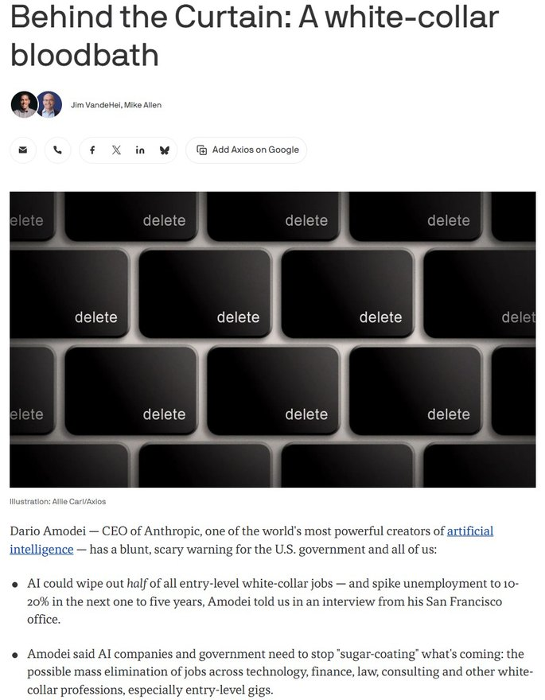

DN, kommentar

Sterk kunstig intelligens kan gi høy ledighet

16. juni 2026

E24, kronikk

KI tar ikke jobbene, men inngangsporten

17. april 2026

Et spørsmål fra Arendalsuka i august

«Juniorer og helt nyutdannede sliter med å komme inn, i hvert fall innen IT-utvikling og kommunikasjon. Det skyldes neppe bare KI. Men vises virkelig ikke dette i statistikken?»

Spørsmålet kom inn på forhånd til Øystein Hernæs' innlegg i Arendalsgata 13. august. Det er et godt spørsmål. Svaret krever at vi er enige om hva vi måler.

Tre svar først

### Ingen jobbkrise

Yrkene der KI kan effektivisere mest, har ikke falt bak yrkene der KI kan effektivisere minst. KI-indeksen er +1,5 prosentpoeng i juli 2026, med standardfeil 2,7.

### Men stigen endres

Unge i flere av de mest KI-eksponerte yrkene har falt. Programvareutviklere 21–30 år ligger på 83 mot oktober 2022 = 100. De eldste i samme yrke ligger på 120.

### Oppgavene avgjør

Hvor KI tas i bruk, bestemmes ikke av hva modellen kan, men av hva det koster å bruke den trygt. De første trinnene på stigen er billigst å automatisere.

Rammeverk · 1

## En jobb er en bunt av oppgaver, og KI treffer dem ulikt

Oppgavene er ti av informasjonsrådgiverens 18 O*NET-oppgaver. Merkelapper fra Eloundou mfl. (2024). Rammeverk: Autor, Levy og Murnane (2003), Acemoglu og Autor (2011).

Rammeverk · 2

## Eksponering er hva KI kan. Bruk er hva det lønner seg å la KI gjøre.

Kostøl (2026), arbeidsnotat. Bygger på Lindenlaub, Oh, Rodríguez og Veldkamp (2026) og Acemoglu og Restrepo (2018).

Rammeverk · 3

## Når KI tar en oppgave, trekker tre krefter i sysselsettingen

Acemoglu og Restrepo (2019), «Automation and New Tasks». Nettoeffekten følger ikke av hva modellen teknisk kan gjøre.

Rammeverk · 4

## Derfor stigen: de nederste trinnene er lettest å sjekke

Garicano (2025) om Beckers problem: juniorene betalte for opplæringen med enkle oppgaver. Imas og Schaal (2026): unge gjør oppgaver med minst kontekst.

Del 2

## Hvordan eksponering måles, oppgave for oppgave

To mål: Eloundou mfl. (2024), som er standard på kiindeksen.no, og Mouchel, Bouquet og Sheffi (2026), som bygger på dokumentert evidens.

Måling · Eloundou mfl. (2024)

## Fra O*NET-oppgaver til én skår per norsk yrke

1 · O*NET

923 yrker, 19 265 oppgaver

Det amerikanske arbeidsdepartementets oppgavebeskrivelser. Hver oppgave er merket kjerne eller tillegg.

2 · Rubrikk

E0, E1 eller E2 per oppgave

E1: en språkmodell alene halverer tiden. E2: halvering med tilleggsprogramvare. E0: ingen av delene. GPT-4 merker, mennesker kontrollerer.

3 · Poeng

β = 1 · E1 + 0,5 · E2

Kjerneoppgaver teller dobbelt. Snittet over oppgavene er yrkets skår.

4 · Kobling

O*NET → SOC → ISCO → STYRK-08

Fire koblinger. Flere koder til én: snitt. Én til flere: kopi. 397 av 407 norske yrkeskoder får skår.

Yrkene rangeres og deles i fem like store grupper. Q1 er minst eksponert, Q5 mest. Indeksen sammenligner Q5 med Q1.

Grupper på 80, 79, 79, 79 og 80 yrker. Dekker 99,8 prosent av sysselsettingen i privat sektor. Kilde: Eloundou, Manning, Mishkin og Rock (2024), Science, og egen kobling.

Måling · et regneeksempel

## Informasjonsrådgivere: 18 oppgaver gir skåren 0,591

STYRK-08 2432, O*NET 27-3031. 15 kjerneoppgaver og 3 tilleggsoppgaver. 1 E0, 4 E1 og 13 E2. Poengsum 19,5 av 33 gir 0,591, som plasserer yrket i Q5. Oppgavetekstene er oversatt fra O*NET.

Måling · tre yrker

## Samme rubrikk, tre yrker: utviklere, kundesenter og elektrikere

Merkelapper: Eloundou mfl. (2024). Bruk: Anthropic Economic Index, 1P API, februar 2026, andel av all trafikk som faller på oppgaven. Oppgavetekstene er forkortet.

Måling · agentisk KI

## Claude Code flyttet terskelen for utviklerne

### Hva som endret seg

- Modellen tar flere steg selv: leser koden, endrer, kjører testene, retter.
- Mennesket kontrollerer sluttresultatet, ikke hvert steg.
- Kontrolltiden per oppgave faller. Flere oppgaver passerer terskelen.

### Hvor lange oppgaver

- METR måler hvor lange programmeringsoppgaver modellene klarer i halvparten av forsøkene.
- Lengden har doblet seg om lag hver fjerde måned siden 2023.
- Claude Code kom som forhåndsversjon i februar 2025, i vanlig salg i mai 2025.

### Derfor to referanser

- ChatGPT: oktober 2022 er siste måned før lanseringen.
- Agentisk KI: januar 2025 er siste måned før Claude Code.
- Begge finnes som valg på kiindeksen.no. Tallene kommer i del 3.

METR (2026), «Measuring AI ability to complete long tasks», lastet ned av Hernæs 3. oktober 2026. Anthropic (2025, 2026), Economic Index.

Måling · Mouchel, Bouquet og Sheffi (2026)

## Et mål bygget på evidens, ikke på modellens magefølelse

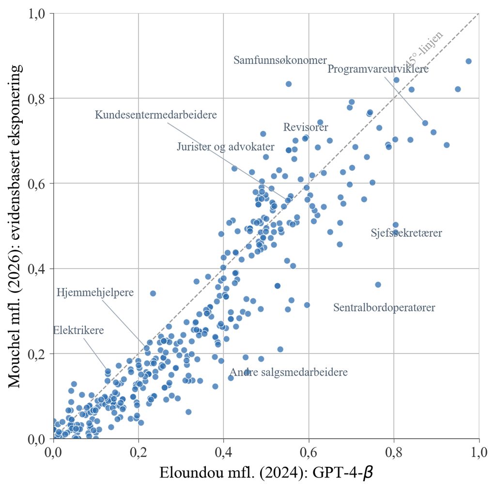

Én prikk per STYRK-08-kode. Grå linje: like verdier. Samfunnsøkonomer og jurister ligger høyere på det nye målet.

Metoden

Hvorfor det er bedre

Uten evidens bytter 20 prosent av merkelappene når bare temperaturen endres. Med evidens under 1,6 prosent. Menneskelige dommere foretrekker den evidensbaserte merkingen i 72 prosent av uenighetene.

Samsvar med Eloundou

ρ = 0,94

66 prosent av yrkene i samme femdel, 99 prosent innen én. Informasjonsrådgivere: 0,59 → 0,71. Utviklere: 0,87 → 0,74.

Måling · hvem er mest eksponert

## Yrke for yrke: grå er Eloundou, blå er Mouchel

[figure not shown]

Antall sysselsatte i parentes. Eloundou er standard på kiindeksen.no fordi det forklarer rapportert KI-bruk best av fire mål: R² 0,30, mot 0,26 for Handa, 0,26 for Felten og 0,02 for Webb (Lindenlaub mfl. 2026, figur 1).

Del 3

## Hva registerdataene viser, til og med juli 2026

Alle ansatte i privat sektor, 21–60 år, hver måned fra januar 2021. Sesongjustert. To referansepunkter: ChatGPT og agentisk KI.

Data · hva KI-indeksen måler

## Fire steg fra registeret til ett tall

1 · Register

A-ordningen

Alle lønnstakerforhold i Norge, status den 16. i hver måned. Via microdata.no.

2 · Utvalg

Privat sektor, 21–60 år

Fordelt på yrke, aldersgruppe og måned. 67 måneder.

3 · Eksponering

Fem grupper

Hvert yrke får sin skår og sin femdel, som i del 2.

4 · Sammenligning

Q5 mot Q1

Vekst i sysselsettingen i de mest eksponerte yrkene mot de minst eksponerte, fra referansemåneden til siste måned.

KI-indeksen = relativ vekst i Q5 mot Q1, i prosentpoeng. Snitt av de tre siste månedene mot snittet av de tre månedene fram til referansen. Usikkerheten kommer fra en bootstrap over yrker.

Hernæs og Kostøl (2026), RFBerlin Discussion Paper 179/26. Metoden står på kiindeksen.no/#metode.

Data · alle aldre 21–60

## De mest eksponerte yrkene har ikke falt bak

[figure not shown]

KI-indeksen, juli 2026 · ChatGPT-referanse

+1,5

prosentpoeng. Standardfeil 2,7. Intervall −3,8 til +6,8.

Vekst siden oktober 2022

Q5 mest eksponert +0,7 %  
Q1 minst eksponert −0,8 %  
Hele privat sektor +1,5 %

KI-indeksen, juli 2026 · agentisk referanse

−0,1

prosentpoeng. Standardfeil 1,1. Intervall −2,3 til +2,1.

Vekst siden januar 2025

Q5 mest eksponert −0,3 %  
Q1 minst eksponert −0,3 %  
Hele privat sektor +0,9 %

Ansatte i privat sektor 21–60 år, sesongjustert, referansemåneden = 100. Femdeler etter Eloundou mfl. (2024). Trykk for å bytte til agentisk referanse.

Data · etter alder, alle yrker

## Heller ikke de yngste faller bak som gruppe

[figure not shown]

Lesing

Hver linje er en aldersgruppe, alle yrker samlet. De yngste ligger ikke lavest. Veksten siden januar 2025 er svak i alle grupper.

Hvorfor det likevel kan skje noe

Bedrifter kan bemanne ned ved å ansette færre, uten å si opp. Det synes først hos dem som skal inn, og i de yrkene der terskelen er passert.

Ansatte i privat sektor etter aldersgruppe, sesongjustert, referansemåneden = 100. Trykk for å bytte referanse.

Data · 21–30 år etter eksponering

## Men blant de yngste faller de mest eksponerte yrkene

[figure not shown]

Unge-indeksen · ChatGPT-referanse

−0,8

Standardfeil 4,0. Intervall −8,6 til +7,0.

Vekst siden oktober 2022, 21–30 år

Mest eksponert −6,6 %  
Minst eksponert −5,8 %  
Begge grupper faller. Det er et bredt ungdomsfall mot 2022.

Unge-indeksen · agentisk referanse

−2,9

Standardfeil 2,0. Intervall −6,9 til +1,1.

Vekst siden januar 2025, 21–30 år

Mest eksponert −4,6 %  
Minst eksponert −1,8 %  
Med Mouchel-målet er unge-indeksen −3,8, intervall −7,2 til −0,4. Det eneste intervallet som ikke dekker null.

Ansatte 21–30 år i privat sektor, sesongjustert, referansemåneden = 100. Stiplet: alle aldre. Siste tolv måneder for unge i Q5: −4,2 %.

Data · ett yrke

## Programvareutviklere: de yngste faller, de eldste vokser

[figure not shown]

21–30 år, juli 2026

83

oktober 2022 = 100

51–60 år, juli 2026

120

Samme yrke, samme periode. STYRK-08 2512–2514 og 2519. Rundt 26 000 ansatte i 2022.

21–30 år, juli 2026

88

januar 2025 = 100

51–60 år, juli 2026

106

Fallet for de yngste begynte før Claude Code, og fortsatte etter.

Ansatte i privat sektor etter aldersgruppe, sesongjustert, referansemåneden = 100. Dette er yrket der Claude Code brukes. Trykk for å bytte referanse.

Data · fire yrkescase fra kiindeksen.no

## To eksponerte yrker og to referanseyrker

[figure not shown]

Ansatte i privat sektor etter aldersgruppe, sesongjustert, oktober 2022 = 100. Egen akse per panel. Prikkede linjer: ChatGPT og Claude Code. 21–30 år i juli 2026: utviklere 83, kundesenter 92, elektrikere 102, hjemmehjelpere 188.

Data · alle spesifikasjoner på ett bilde

## Ett intervall av åtte holder seg unna null

[figure not shown]

KI-indeksen i juli 2026 for to mål, to referanser og to aldersgrupper. Punkt: bootstrap-estimatet. Strek: 95 prosent intervall fra 1 000 trekk over yrker. Grå: Eloundou. Blå: Mouchel.

Andre land · oversikt etter Imas og Schaal (2026)

## Samme mønster i USA, Sverige og Storbritannia

### Forklaringer som konkurrerer

- Fjernarbeid følger eksponering tett, rangkorrelasjon 0,77. Lambert og Schindler (2026).
- Renter og normalisering etter pandemien. Imas og Schaal (2026).

### Foretak som tar i bruk KI

- Danmark: ingen effekt over 2 prosent på lønn og timer. Humlum og Vestergaard (2026).
- USA: 7,7 prosent færre juniorer etter seks kvartaler. Hosseini og Lichtinger (2025).
- 41 land: juniorandelen 1,9 prosentpoeng lavere. Chandar og Klein Teeselink (2026).

### Samlet stabilitet

- USA: ledigheten for nyutdannede på nivå med 2022–2025. Fairlie og Wu (2026).
- Norge: KI-indeksen +1,5, standardfeil 2,7.

Tallene er kontrollert mot originalstudiene av Hernæs 3. oktober 2026.

Svaret på spørsmålet fra Arendalsuka

## Vises det i statistikken? Ja, noe. Men ikke bredt.

### Dette ser vi

- Unge i de mest eksponerte yrkene: −6,6 prosent siden oktober 2022, −4,6 siden januar 2025. De eldre i samme yrker vokser.
- Utviklere 21–30 år på 83, kundesenter på 92, mot 100 i oktober 2022.
- Skillet mellom unge i mest og minst eksponerte yrker åpner seg etter agentisk KI.

### Dette ser vi ikke

- Noe bredt fall i de mest eksponerte yrkene samlet, eller for 21–30-åringene samlet.
- Hva som driver fallet: erstattet av KI, junioroppgaver som forsvinner, strengere krav eller seniorer som rekker mer. Renter og konsulentkutt er også med.
- Offentlig sektor i hovedtallet. Den har egne figurer på kiindeksen.no.

Indeksen er et beskrivende vekstgap, ikke en årsakseffekt. Yrkeskodene er fra 2011 og oppgavene amerikanske. Feil i kodingen visker ut forskjeller heller enn å skape dem.

Hva som kan gjøres

## Forslag fra forskning og debatt, og råd til dem som skal inn

| Inngang | Inntekt under omskolering, flere lønnstilskudd, traineestillinger og mål for nyutdannede i staten. | Kostøl og Harang, DN juli 2026 |
| --- | --- | --- |
| Opplæring | Staten betaler sertifisert opplæring og lærlingløp når juniorarbeidet ikke lenger finansierer læringen. | Garicano (2025), Garicano og Rayo (2025) |
| Skatt | Skatt som ikke favoriserer maskiner framfor ansatte. Offentlige innkjøp av KI som gjør ansatte bedre. | Harang og Kostøl, DN juni 2026. Acemoglu, Autor og Johnson (2026) |
| Beredskap | Følg utviklingen, stresstest, skalerbart sikkerhetsnett. | Korinek (2023) |

### Råd til unge

- Bruk KI på virkelige oppgaver. Dokumenter arbeidsmåten, finn feilene, sjekk kildene.
- Gjør et eget forsøk først. Kontrollkompetansen er den nye inngangen.
- Fullfør grad eller fagbrev, og lær KI i selve faget.
- Spør arbeidsgiver hvordan de trener juniorer når rutineoppgavene blir færre.

Forslagene er hentet fra kildene og ikke evaluert som én samlet pakke. Rådene bygger på Mollick (2023), Deming (2025), Brynjolfsson (2026) og Garicano (2025).

Følg med videre

## kiindeksen.no oppdateres hver måned

[figure not shown]

Velg selv

Utfall, aldersgruppe, eksponeringsmål, referanse, enkeltyrker, utdanning og offentlig sektor. Alt kan lastes ned.

Forskningsartikkelen

Hernæs og Kostøl (2026), «Has AI Widened Employment Gaps?», RFBerlin Discussion Paper 179/26.

Engelsk

kiindeksen.no/en

Øystein Hernæs, Frischsenteret · Andreas R. Kostøl, Handelshøyskolen BI. Skjermbilde 5. oktober 2026.

← → bla · N notater · F fullskjerm

Talenotater